# Consumo de alimento en salmones bajo 20% de actividad y su relación con FCRc y SGRc

Pedro Pizarro

25 May 2022

### Base de datos

Los datos a utilizar corresponden a una base de datos con 7 variables: Año de cultivo **(Year_class)**, unidad de cultivo **(Jaula)** ,fecha en que se cosechó la jaula **(Fecha_cosecha)**, el alimento consumido bajo 20% de actividad **(Consumo_bajo_20)**, factor de conversión corregido **(FCRc)** y tasa de crecimiento específica corregida **(SGRc)**. Los datos están balanceados.

```r
read_excel("Base_Datos_Cons_FCR_SGR.xlsx")
```

```
## # A tibble: 269 × 7
##    Year_class Fecha_cosecha       Centro    Jaula   `Consumo_ bajo…`  FCRc  SGRc
##         <dbl> <dttm>              <chr>     <chr>              <dbl> <dbl> <dbl>
##  1       2021 2021-08-29 00:00:00 Chivato 1 Chivat…           0.0201 0.892  1.13
##  2       2021 2021-09-02 00:00:00 Chivato 1 Chivat…           0.0156 0.91   1.10
##  3       2021 2021-09-07 00:00:00 Chivato 1 Chivat…           0.0754 0.968  1.05
##  4       2021 2021-09-18 00:00:00 Chivato 1 Chivat…           0.0579 0.966  1.06
##  5       2021 2021-09-20 00:00:00 Chivato 1 Chivat…           0.0375 0.942  1.04
##  6       2021 2021-09-23 00:00:00 Chivato 1 Chivat…           0.0715 0.911  1.07
##  7       2021 2021-09-23 00:00:00 Chivato 1 Chivat…           0.0721 0.985  1.06
##  8       2021 2021-09-29 00:00:00 Chivato 1 Chivat…           0.0775 0.966  1.08
##  9       2021 2021-10-01 00:00:00 Chivato 1 Chivat…           0.0383 0.932  1.05
## 10       2021 2021-10-03 00:00:00 Chivato 1 Chivat…           0.0274 0.936  1.05
## # … with 259 more rows
```

```r
BDatos <-read_excel("Base_Datos_Cons_FCR_SGR.xlsx")
```

```r
summary(BDatos)
```

```
##    Year_class   Fecha_cosecha                    Centro
##  Min.   :2020   Min.   :2020-07-16 00:00:00   Length:269
##  1st Qu.:2021   1st Qu.:2021-01-26 00:00:00   Class :character
##  Median :2021   Median :2021-05-12 00:00:00   Mode  :character
##  Mean   :2021   Mean   :2021-05-18 21:24:45
##  3rd Qu.:2021   3rd Qu.:2021-08-26 00:00:00
##  Max.   :2022   Max.   :2022-10-11 00:00:00
##     Jaula           Consumo_ bajo_ 20      FCRc            SGRc
##  Length:269         Min.   :0.00000   Min.   :0.862   Min.   :0.713
##  Class :character   1st Qu.:0.02613   1st Qu.:0.966   1st Qu.:0.978
##  Mode  :character   Median :0.07150   Median :1.009   Median :1.008
##                     Mean   :0.08566   Mean   :1.011   Mean   :1.007
##                     3rd Qu.:0.12305   3rd Qu.:1.046   3rd Qu.:1.050
##                     Max.   :0.40443   Max.   :1.223   Max.   :1.189
```

En el resumen, las características de los datos de las variables recomiendan la transformación a factor de algunas de ellas.

```r
BDatos$Year_class <- as.factor(BDatos$Year_class)
BDatos$`Fecha_cosecha` <- as.factor(BDatos$`Fecha_cosecha`)
BDatos$Jaula <-as.factor(BDatos$Jaula)
BDatos$Centro <- as.factor (BDatos$Centro)
summary(BDatos)
```

```
##  Year_class    Fecha_cosecha         Centro             Jaula
##  2020: 51   2021-04-21: 13   Orestes    : 24   Chivato 1101:  1
##  2021:187   2020-08-27:  6   Elena Weste: 22   Chivato 1102:  1
##  2022: 31   2020-08-13:  3   Punta Cola : 22   Chivato 1103:  1
##             2021-01-10:  3   Punta Rouse: 22   Chivato 1104:  1
##             2021-02-11:  3   Williams 1 : 22   Chivato 1105:  1
##             2021-04-30:  3   Elena Norte: 21   Chivato 1106:  1
##             (Other)   :238   (Other)    :136   (Other)     :263
##  Consumo_ bajo_ 20      FCRc            SGRc
##  Min.   :0.00000   Min.   :0.862   Min.   :0.713
##  1st Qu.:0.02613   1st Qu.:0.966   1st Qu.:0.978
##  Median :0.07150   Median :1.009   Median :1.008
##  Mean   :0.08566   Mean   :1.011   Mean   :1.007
##  3rd Qu.:0.12305   3rd Qu.:1.046   3rd Qu.:1.050
##  Max.   :0.40443   Max.   :1.223   Max.   :1.189
##
```

```r
str(BDatos)
```

```
## tibble [269 × 7] (S3: tbl_df/tbl/data.frame)
##  $ Year_class       : Factor w/ 3 levels "2020","2021",..: 2 2 2 2 2 2 2 2 2 2 ...
##  $ Fecha_cosecha    : Factor w/ 201 levels "2020-07-16","2020-08-01",..: 147 149 151 154 155 157 157 159 160 161 ...
##  $ Centro           : Factor w/ 16 levels "Chivato 1","Concheo 1",..: 1 1 1 1 1 1 1 1 1 1 ...
##  $ Jaula            : Factor w/ 269 levels "Chivato 1101",..: 18 17 14 10 2 8 9 7 1 15 ...
##  $ Consumo_ bajo_ 20: num [1:269] 0.0201 0.0156 0.0754 0.0579 0.0375 0.0715 0.0721 0.0775 0.0383 0.0274 ...
##  $ FCRc             : num [1:269] 0.892 0.91 0.968 0.966 0.942 0.911 0.985 0.966 0.932 0.936 ...
##  $ SGRc             : num [1:269] 1.13 1.1 1.05 1.06 1.04 ...
```

Las variables de mayor interés en este caso son **Consumo_bajo_20**, **FCRc** y **SGRc** que son variables cuantitativas continuas, mostrando al aplicar la función de densidad empírica y la función de distribución empírica acumulada la forma de la curva característica de este tipo de variables.

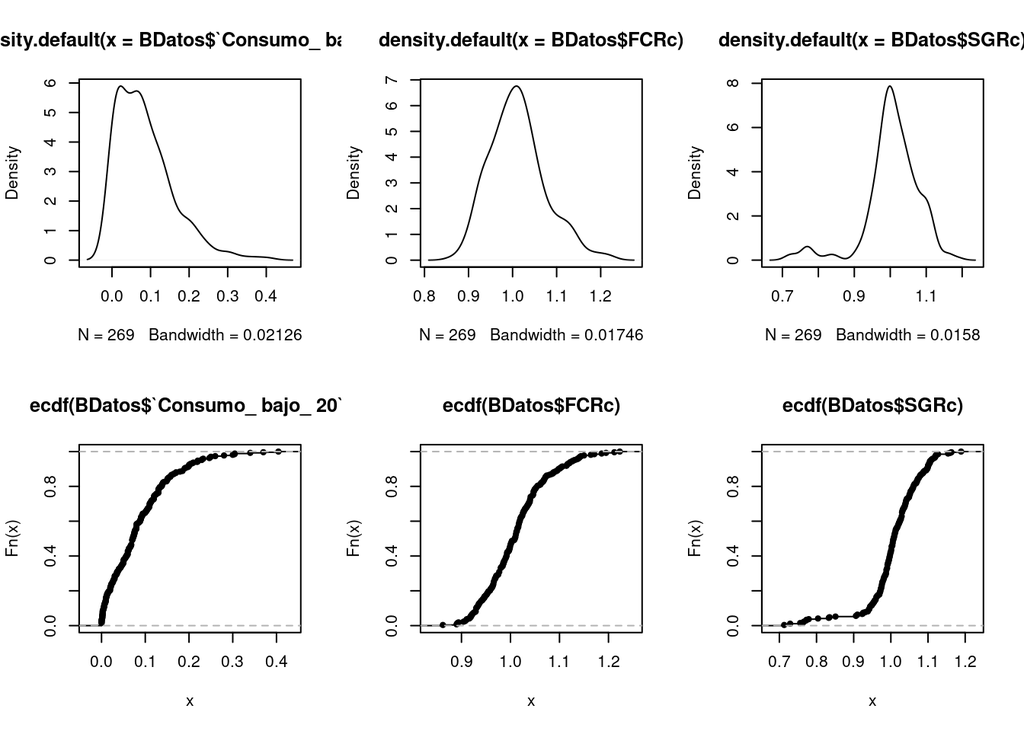

```r
par(mfrow=c(2,3))
plot (density(BDatos$`Consumo_ bajo_ 20`))
plot (density(BDatos$FCRc))
plot (density(BDatos$SGRc))
plot (ecdf(BDatos$`Consumo_ bajo_ 20`))
plot (ecdf(BDatos$FCRc))
plot (ecdf(BDatos$SGRc))
```

En la base de datos importada, los valores de las variables de estudio estaban en formato “número” y para una mejor comprensión estas variables deben expresarse en porcentajes. Por lo tanto, se realiza la transformación de estas a % y se seleccionan las variables de mayor interés para el estudio preliminar.

```r
BDatos_mod <-BDatos %>% mutate(Consumo_20=`Consumo_ bajo_ 20` *100 , FCRc_porc=FCRc*100, SGRc_porc=SGRc*100) %>% select (Year_class, Centro, Consumo_20, FCRc_porc,SGRc_porc)
summary (BDatos_mod)
```

```
##  Year_class         Centro      Consumo_20       FCRc_porc       SGRc_porc
##  2020: 51   Orestes    : 24   Min.   : 0.000   Min.   : 86.2   Min.   : 71.3
##  2021:187   Elena Weste: 22   1st Qu.: 2.613   1st Qu.: 96.6   1st Qu.: 97.8
##  2022: 31   Punta Cola : 22   Median : 7.150   Median :100.9   Median :100.8
##             Punta Rouse: 22   Mean   : 8.566   Mean   :101.1   Mean   :100.7
##             Williams 1 : 22   3rd Qu.:12.305   3rd Qu.:104.6   3rd Qu.:105.0
##             Elena Norte: 21   Max.   :40.443   Max.   :122.3   Max.   :118.9
##             (Other)    :136
```

```r
str(BDatos_mod)
```

```
## tibble [269 × 5] (S3: tbl_df/tbl/data.frame)
##  $ Year_class: Factor w/ 3 levels "2020","2021",..: 2 2 2 2 2 2 2 2 2 2 ...
##  $ Centro    : Factor w/ 16 levels "Chivato 1","Concheo 1",..: 1 1 1 1 1 1 1 1 1 1 ...
##  $ Consumo_20: num [1:269] 2.01 1.56 7.54 5.79 3.75 7.15 7.21 7.75 3.83 2.74 ...
##  $ FCRc_porc : num [1:269] 89.2 91 96.8 96.6 94.2 91.1 98.5 96.6 93.2 93.6 ...
##  $ SGRc_porc : num [1:269] 113 110 105 106 104 ...
```

```r
Mi_gráfico = theme(axis.title.x = element_text(size = 16), axis.text.x = element_text(size = 12), axis.title.y = element_text(size = 16), axis.text.y = element_text(size = 12))
Mi_gráfico_2 = theme(axis.title.x = element_text(size = 16), axis.text.x = element_text(angle =45 , vjust= 1,0 , hjust= 1,0, size = 12), axis.title.y = element_text(size = 16), axis.text.y = element_text(size = 12))
```

Los histogramas construidos para las tres variables demuestran que habrían valores atípicos de manera más marcada en los datos de las variables de consumo bajo 20% de actividad y SGRc.

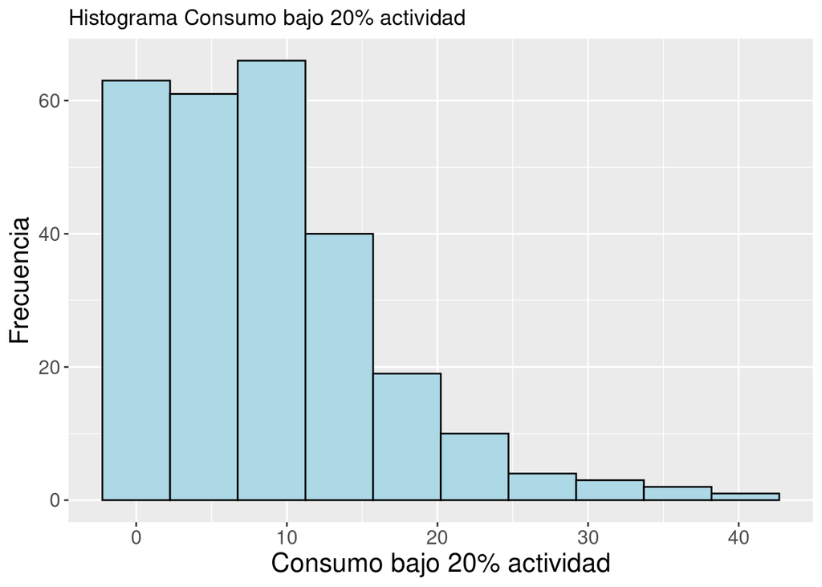

```r
ggplot(BDatos_mod, aes(Consumo_20))+theme_gray()+
  geom_histogram(bins = 10, color= "black",fill="light blue")+
  labs(title="Histograma Consumo bajo 20% actividad", x="Consumo bajo 20% actividad", y="Frecuencia")+ Mi_gráfico
```

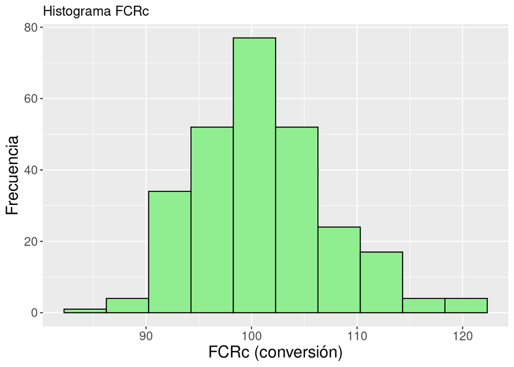

```r
ggplot(BDatos_mod, aes(FCRc_porc))+theme_gray()+
  geom_histogram(bins = 10, color= "black",fill="light green")+
  labs(title="Histograma FCRc", x="FCRc (conversión)",y="Frecuencia")+ Mi_gráfico
```

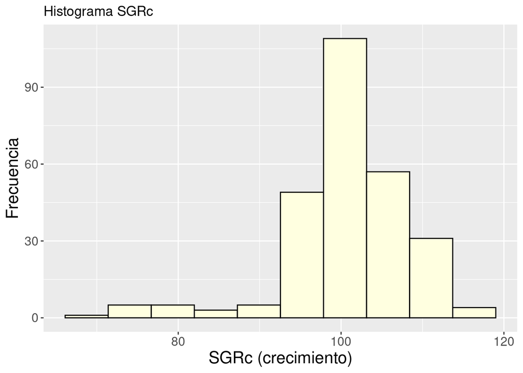

```r
ggplot(BDatos_mod, aes(SGRc_porc))+theme_gray()+
  geom_histogram(bins = 10, color= "black",fill="light yellow")+
  labs(title="Histograma SGRc", x="SGRc (crecimiento)",
       y="Frecuencia")+ Mi_gráfico
```

Los gráficos de caja a partir de Centro de cultivo para las variables FCRc y SGRc indican diversa variabilidad de los datos entre centros y valores atípicos que deben investigarse para su probable eliminación. Para una mejor visualización de los gráficos, lo nombres de los centros se reemplazan en algunos casos y en otros, se utiliza como nuevo identificador las tres primeras letras del nombre.

```r
BDatos_mod_2 <- BDatos_mod
BDatos_mod_2$Centro <- str_replace_all (BDatos_mod$Centro, c("Elena Norte" = "ElN", "Elena Weste"="ElW", "Punta Cola"= "PCo", "Punta Rouse"= "PRo"))
BDatos_mod_2 <- BDatos_mod_2 %>% mutate (ID_Centro= substr(Centro,1,3))
```

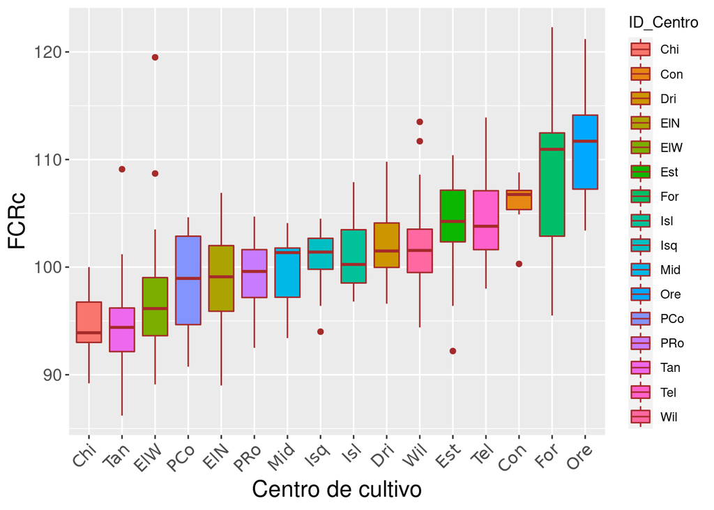

```r
ggplot(BDatos_mod_2 , aes(x=reorder(ID_Centro , FCRc_porc) , y=FCRc_porc , fill= ID_Centro)) + geom_boxplot(color= "brown") + labs( x="Centro de cultivo", y="FCRc") + Mi_gráfico_2
```

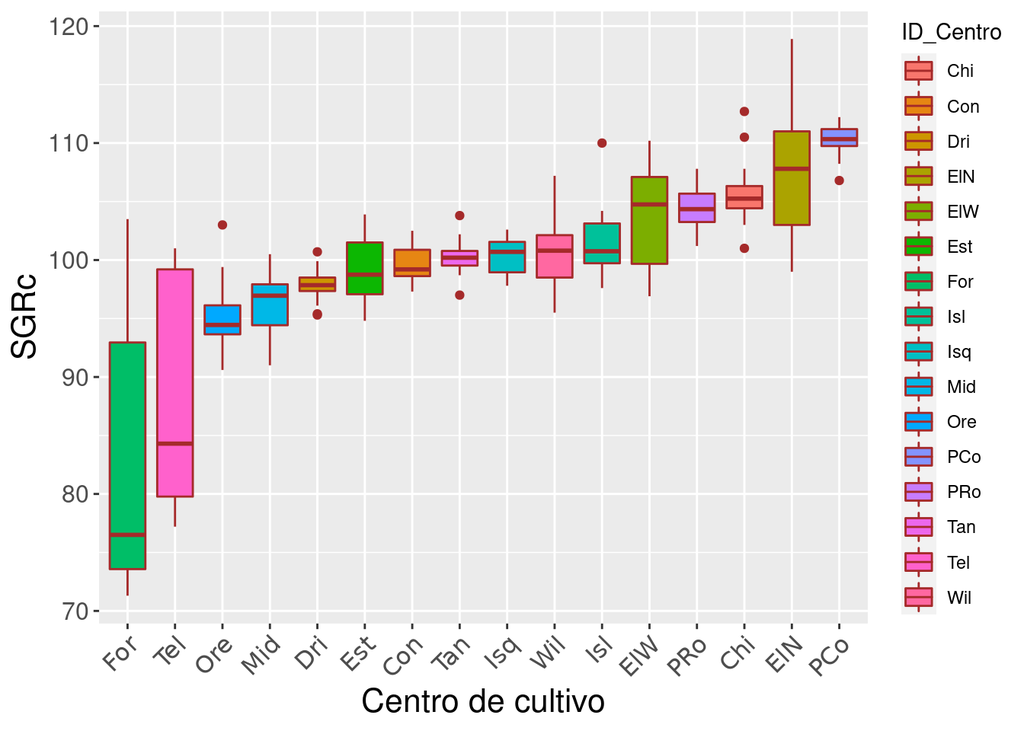

```r
ggplot(BDatos_mod_2 , aes(x= reorder(ID_Centro ,SGRc_porc), y=SGRc_porc ,fill=ID_Centro)) +
    geom_boxplot(color= "brown") + labs( x="Centro de cultivo" , y="SGRc")+ Mi_gráfico_2
```

En los gráficos de dispersión a partir de Consumo de alimento bajo 20% para FCRc y SFRc se puede observar la correlación entre las variables, con tendencia a aumentar el FCRc y disminuir el SGRc a medida que aumenta el consumo de alimento bajo 20% de actividad.

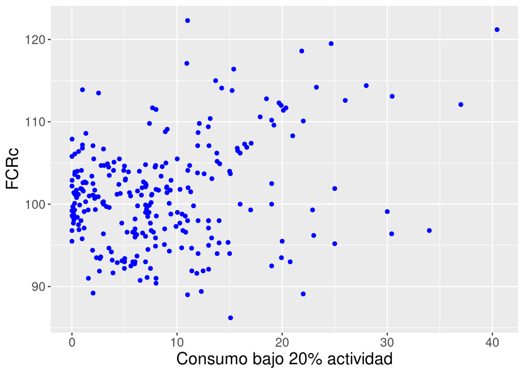

```r
ggplot(BDatos_mod , aes(x= Consumo_20 , y=FCRc_porc)) +
    geom_point(color= "blue") + labs( x="Consumo bajo 20% actividad" , y="FCRc")+ Mi_gráfico
```

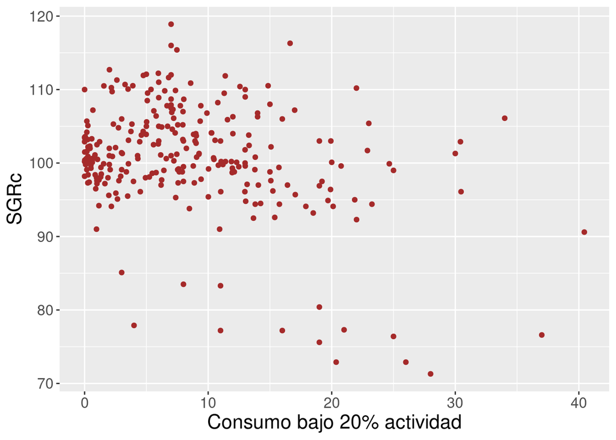

```r
ggplot(BDatos_mod , aes(x= Consumo_20 , y=SGRc_porc)) +
    geom_point (color= "brown") + labs( x="Consumo bajo 20% actividad" , y="SGRc")+ Mi_gráfico
```

Se construye una nueva tabla agrupando por Centro y considerando el promedio de cada variable de estudio.

```r
BDatos_mod %>% group_by(Centro) %>% summarise(Consumo20_prom = mean(Consumo_20), FCRc_prom = mean(FCRc_porc), SGRc_prom =mean(SGRc_porc))
```

```
## # A tibble: 16 × 4
##    Centro       Consumo20_prom FCRc_prom SGRc_prom
##    <fct>                 <dbl>     <dbl>     <dbl>
##  1 Chivato 1             5.08       94.6     106.
##  2 Concheo 1             3.90      106.       99.7
##  3 Dring 1               5.43      102.       97.8
##  4 Elena Norte          12.4        98.8     108.
##  5 Elena Weste          15.6        97.6     104.
##  6 Ester                13.7       104.       99.3
##  7 Forsyth              16.6       109.       82.5
##  8 Isla Level 2          0.242     101.      102.
##  9 Isquiliac             6.54      101.      100.
## 10 Midhurst              1.19       99.7      96.5
## 11 Orestes              17.9       111.       95.1
## 12 Punta Cola            6.62       98.4     110.
## 13 Punta Rouse           7.91       99.2     105.
## 14 Tangbac               9.68       94.9     100.
## 15 Tellez                8.17      105.       88.4
## 16 Williams 1            1.54      102.      101.
```

```r
BDatos_gcentro <- BDatos_mod %>% group_by(Centro) %>% summarise(Consumo20_prom = mean(Consumo_20), FCRc_prom = mean(FCRc_porc), SGRc_prom =mean(SGRc_porc))
```

De la tabla anterior de filtran los % de consumo bajo el 20% de actividad mayores a 12%

```r
BDatos_gcentro %>% filter(Consumo20_prom > 12)%>%arrange(-Consumo20_prom)
```

```
## # A tibble: 5 × 4
##   Centro      Consumo20_prom FCRc_prom SGRc_prom
##   <fct>                <dbl>     <dbl>     <dbl>
## 1 Orestes               17.9     111.       95.1
## 2 Forsyth               16.6     109.       82.5
## 3 Elena Weste           15.6      97.6     104.
## 4 Ester                 13.7     104.       99.3
## 5 Elena Norte           12.4      98.8     108.
```

```r
BDatos_top <- BDatos_gcentro %>% filter(Consumo20_prom > 12)%>%arrange (-Consumo20_prom)
```

En el gráfico, la línea de tendencia indica que a mayor consumo de alimento bajo el 20% de actividad el FCRc aumentaría (considerando todos los datos).

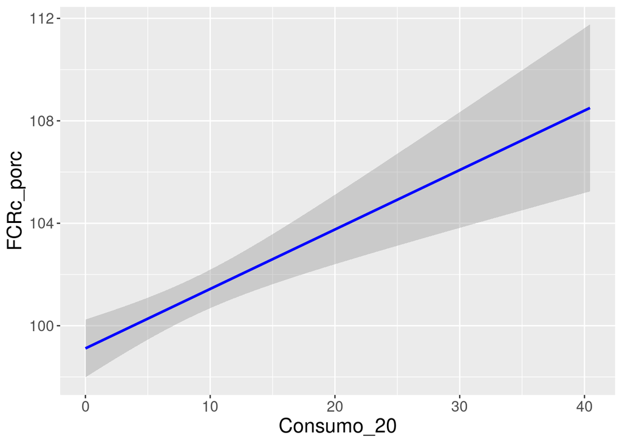

```r
 ggplot(BDatos_mod , aes(x= Consumo_20 , y=FCRc_porc))+ geom_smooth(method = "lm",  se= TRUE , color= "blue") + Mi_gráfico
```

En el gráfico, la línea de tendencia indica que a mayor consumo de alimento bajo el 20% de actividad el SGRc disminuiría (considerando todos los datos).

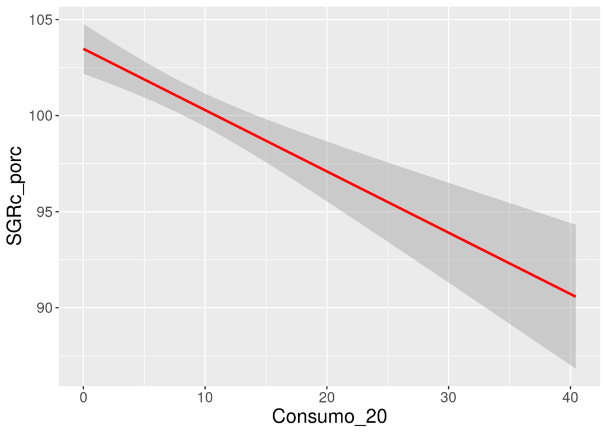

```r
 ggplot(BDatos_mod , aes(x= Consumo_20 , y=SGRc_porc))+ geom_smooth(method = "lm", se= TRUE, color= "red")  + Mi_gráfico
```

Existe correlación entre las variables, sin embargo el coeficiente de correlación en ambos casos es débil

```r
cor(BDatos_mod$Consumo_20 , BDatos_mod$FCRc_porc)
```

```
## [1] 0.2703432
```

```r
cor(BDatos_mod$Consumo_20 , BDatos_mod$SGRc_porc)
```

```
## [1] -0.31807
```

Cuando se considera la selección de los centros con los consumos más altos bajo 20% de de actividad y su relación con las variables FCRc y SGRc la correlación aumenta de manera considerable en ambos casos. La correlación entre consumo bajo 20% y FCRc es positiva, es decir, el aumento de una variable significa un aumento de la otra, a diferencia de la correlación negativa que demuestra la variable SGRC.

```r
head(BDatos_top)
```

```
## # A tibble: 5 × 4
##   Centro      Consumo20_prom FCRc_prom SGRc_prom
##   <fct>                <dbl>     <dbl>     <dbl>
## 1 Orestes               17.9     111.       95.1
## 2 Forsyth               16.6     109.       82.5
## 3 Elena Weste           15.6      97.6     104.
## 4 Ester                 13.7     104.       99.3
## 5 Elena Norte           12.4      98.8     108.
```

```r
cor(BDatos_top$Consumo20_prom , BDatos_top$FCRc_prom)
```

```
## [1] 0.7431022
```

```r
cor(BDatos_top$Consumo20_prom , BDatos_top$SGRc_prom)
```

```
## [1] -0.6659266
```